# MATES_analysis

The utmost important thing happens before MATES comes into play: professional data stratification. This is where ALL meta-analysis in ecology - plant sciences I have seen failed completely. The reason: it is done by non-biology experts, people in maths or stats.

Very important

standard procedure

Moderately important

once the software and its version is reported, this seems like less important

Extremely important

If what you call the ‘first model’ means the basic structure of the analysis, this is possibly the most important step. Qualified data stratification and data sorting by co-variable is the alpha and omega of meta-analysis. The rest is maths

Extremely important

Most often, the justification of how (and why) data were structured in the way this was done is insufficient.

Extremely important

If weighing is supposed to indicate the weight of certain frame conditions he data are nested in, this is super important. To give you an example: An analysis for the influence of CO2 on plant growth is completely worthless unless the concurrent nutrition of plants is accounted for in a trustworthy, educated manner.

Extremely important

There is no such thing as non-independence. That is the central problem of meta-analysis. There is always a confounding influence. We see a flood of meta-analysis (recently mostly from researchers in China), that irons the data flat. Whatever response meta-analysis aims at distilling depends on the quality of the handling of confounding variables. This is not normally something that statistics experts can do. In the end we often see meta-analysis the outcome of which reflects the frequency distribution of methods. For instance, if 95% of the data come from potted plants and 5% from trees in nature, the outcome will be dominated by what potted plants do, no matter how sophisticated the meta-analysis is.

Moderately important

I cannot answer this. I do not understand the question

Extremely important

If, what you call ‘moderator variable’ is what I would call confounding variable or interactive variable, that this is the most important of all points. See my earlier comments. Your phrasing reads a bit cryptic to me.

Extremely important

Again, if this refers to biased data handling (e.g. not stratifying data by things like age of people, or nutrition of plants, or experimental conditions such as indoor vs outdoor etc.) this is key.

Extremely important

sure you want to see the power of the analysis, for instance how sensitive the analysis is with regard to the inclusion or exclusion of certain criteria by which the data were stratified (sorted)

Extremely important

Trivial, of course you need to describe your sample and what its structure is

Extremely important

there should be no such analysis without descriptive stats upfront

Moderately important

nice to have, but if it hides or masks things because of two dimensional description of what is multidimensional they can also disguise the reality

Extremely important

you mean descriptive stats upfront? The raw tables with what had been entered into the analysis must be reported in supplementary archives. That archive should already structured in a way how the data were used in the analysis.

Extremely important

I think this refers to the before mentioned archive. The listing must show the criteria (codes) by which the data were stratified in the analysis

The most important thing happens before meta-analysis. I saw only biased meta-analysis because this data handling was left to software and stats people. The sorting of data and the specification of co-variables and interactive terms must be decided by the best experts of the subject. Possible by a consortium of experts. The technical part that follows is of secondary importance.

I have not worked with MATES, but I have seen many meta-analysis and actually published two- or three-times on their miserable handling in prominent journals. In all cases the analysis led to highly biased results, because the data were not properly stratified. This is the hard job. Because you need to read and UNDERSTAND the papers in order to rank the data BEFORE entering meta-analysis.

NA

Early career researcher

NA

Author,Reviewer

NA

No experience

NA

Very important

NA

NA

NA

NA

NA

NA

NA

NA

NA

NA

NA

NA

NA

NA

NA

NA

NA

NA

NA

NA

NA

NA

NA

NA

NA

NA

NA

NA

NA

NA

NA

NA

NA

NA

NA

NA

Senior career researcher

NA

Author

NA

I have used an appraisal tool(s)

I’ve used meta-analyses

Very important

NA

Very important

NA

Slightly important

NA

Very important

NA

Moderately important

NA

Moderately important

NA

Moderately important

NA

Moderately important

NA

Very important

NA

Extremely important

NA

Very important

NA

Slightly important

NA

Extremely important

NA

Extremely important

NA

Extremely important

NA

Moderately important

NA

Moderately important

NA

NA

NA

NA

Senior career researcher

NA

Author,Reviewer

NA

No experience

NA

Very important

NA

Very important

NA

Very important

NA

Very important

NA

Very important

NA

Very important

NA

Extremely important

NA

Extremely important

NA

Extremely important

NA

Very important

NA

Very important

NA

Very important

NA

Very important

NA

Extremely important

NA

Very important

NA

Extremely important

NA

Extremely important

NA

NA

NA

NA

Middle career researcher

NA

Author,Reviewer

NA

I have used an appraisal tool(s)

GRADE; AMSTAR; NOS

Moderately important

According to my experience, software is not important for doing meta-analysis, and the results from different softwares are always similar

Slightly important

Still, this would be useful for other authors to replicate the review, but for meta-analysis itself is not important

Not at all important

No

Moderately important

It would be helpful for other researchers, but this can just be provided in the supplements

Very important

NA

Very important

NA

Very important

NA

Very important

NA

Extremely important

NA

Very important

NA

Extremely important

NA

Extremely important

NA

Extremely important

NA

Extremely important

NA

Moderately important

NA

Extremely important

NA

Extremely important

NA

1. Funding information of the meta-analyses;
2. Risk of bias assessment
3. Study quality assessment
4. Non-linear pooling, if possible

No

NA

Middle career researcher

NA

Author

NA

No experience

NA

Extremely important

NA

Extremely important

NA

Moderately important

NA

NA

NA

NA

NA

NA

NA

NA

NA

NA

NA

NA

NA

NA

NA

NA

NA

NA

NA

NA

NA

NA

NA

NA

NA

NA

NA

NA

NA

NA

NA

NA

Middle career researcher

NA

Author

NA

No experience

NA

NA

NA

NA

NA

NA

NA

NA

NA

NA

NA

NA

NA

NA

NA

NA

NA

NA

NA

NA

NA

NA

NA

NA

NA

NA

NA

NA

NA

NA

NA

NA

NA

NA

NA

NA

NA

NA

Other

Senior Analyst (15 years post PhD)

Author

NA

I have used an appraisal tool(s)

CEECAT

Very important

NA

Very important

NA

Slightly important

NA

Moderately important

NA

Very important

NA

Moderately important

NA

Very important

NA

Extremely important

NA

Very important

NA

Extremely important

If a meta-regression is conducted it is of course extremely important to report the moderator variables, but that is not the same as saying that it is extremely important to conduct a meta-regression.

Very important

Although it is important to report a test or measure of publication bias, it is as important to keep in mind that it is quite hard to test for publication bias and that all those measures may be interpreted in different ways.

Very important

Here you may want to be a bit more specific about what the sensitivity analysis should be based on (e.g., critical appraisal assessment or other subgroups). Also, do you include for example fail-safe number analysis to test robustness here?

Extremely important

NA

Extremely important

NA

Moderately important

NA

Extremely important

NA

Moderately important

NA

NA

NA

NA

Early career researcher

NA

Author

NA

I have used an appraisal tool(s)

systematic literature review for ecosystem services

NA

NA

NA

NA

NA

NA

NA

NA

NA

NA

NA

NA

NA

NA

NA

NA

NA

NA

NA

NA

NA

NA

NA

NA

NA

NA

NA

NA

NA

NA

NA

NA

NA

NA

NA

NA

NA

Early career researcher

NA

Author

NA

No experience

NA

Extremely important

NA

Extremely important

NA

Extremely important

NA

Extremely important

NA

Extremely important

NA

Extremely important

NA

Moderately important

This criteria seems more study-specific than the previous metrics

Moderately important

NA

Moderately important

NA

Extremely important

NA

Extremely important

NA

Moderately important

NA

Extremely important

NA

Extremely important

NA

Moderately important

NA

Extremely important

NA

Extremely important

NA

Appropriate methods for number of studies / effect sizes included

NA

NA

Middle career researcher

NA

Author

NA

I have heard of an appraisal tool(s)

NA

Very important

To ensure accurate comparison, reproduction, and discussion of results, it is crucial to provide detailed information about the software used for analysis. Even slight differences in software versions must be reported.

Very important

If the package has slight differences that can result in distinct outcomes, it will be the same as the previous question. Then is it important report the details.

Very important

New versions have improvements or changes in the algorithms or the routines that can make differences.

Very important

NA

Very important

NA

Very important

If the first model was discarded, it is crucial to know the first approach that the authors used, in order to evaluate the improvements and changes on the final model.

Very important

In addition to reporting the weighting, the authors must declare the criteria with which they established the weights of each response to make them comparable between the different studies analyzed.

Extremely important

To avoid biased results, it is important to report a non-independent effect size estimated.

Very important

Some statistical tests assume the homogeneity between effect size estimates. So, the authors must let the readers know how they deal with the heterogeneity.

Very important

NA

Extremely important

NA

Extremely important

Sensitivity analyses provide valuable information because even the most detailed meta-analysis can let outside other sources of information. So, knowing which results are less or more sensitive to excluding information is crucial.

Extremely important

This is related to the previous question. The readers need to know how many studies were included in the meta-analysis because slight differences in the number of studies can lead to distinct results if the sensitivity is high.

Extremely important

NA

Extremely important

At least for me, a visual presentation of the obtained results is easy to understand and compare.

Extremely important

If anyone wants to reproduce the meta-analysis, sharing the original sources and the raw database is extremely important.

Extremely important

NA

You did a very detailed job and included all the necessary elements to assess the quality of the meta-analysis.

Thank you for considering my thoughts and opinions in your survey. And best luck.

NA

Senior career researcher

NA

Author

NA

I have heard of an appraisal tool(s)

NA

Extremely important

NA

Extremely important

NA

Very important

NA

Extremely important

NA

Very important

NA

Very important

NA

Very important

NA

Extremely important

NA

Extremely important

NA

Moderately important

NA

Very important

NA

Very important

NA

Extremely important

NA

Very important

NA

Very important

NA

Moderately important

NA

Moderately important

NA

NA

NA

NA

Middle career researcher

NA

Author,Reviewer,Editor

NA

I have used an appraisal tool(s)

Cochrane risk of bias; JBI tools; ROBINS-I

NA

NA

NA

NA

NA

NA

NA

NA

NA

NA

NA

NA

NA

NA

NA

NA

NA

NA

NA

NA

NA

NA

NA

NA

NA

NA

NA

NA

NA

NA

NA

NA

NA

NA

NA

NA

NA

Middle career researcher

NA

Author

NA

I have used an appraisal tool(s)

We used the tool developed by Konno et al (2021) for critical appraisal of study validity. REF: Konno K, Livoreil B, Pullin A. Collaboration for Environmental Evidence Critical Appraisal Tool version 0.3 (prototype). 2021. Available from: https://environmentalevidence.org/cee-critical-appraisal-tool/

Extremely important

I think it is very important that all steps in conducting the meta-analyses are reported so that the process is as transparent as possible. Beyond reporting the software used, I think it is important to share codes to improve repeatability of analyses and also facilitate learning best practices.

Very important

Reporting needs to be clear and precise, and main packages (and versions used) should be reported. Since the number of packages can quickly add up, additional packages could be listed in the scripts.

Very important

See my previous answer ;)

Extremely important

I think reporting the code should be considered a standard practice, as it helps with the repeatability and transparency of analyses, and also helps others learn how analyses can be conducted. For the last meta-analyses we conducted, I found extremely useful to have the recent paper of Nakagawa et al (2023) at hand at all times :) (REF: https://environmentalevidencejournal.biomedcentral.com/articles/10.1186/s13750-023-00301-6)

Very important

I am not sure what is referred to as primary (or first) model – but the rationale of how and why the model is built as it is, should be clearly explained and reasoned (this is why I responded “very important” to this question)

Extremely important

I think this answer reflects actually how I understood the previous question

Very important

NA

Very important

Yes! And very often underreported (or not even considered)

Very important

NA

Extremely important

I guess including moderator variables would be part of the hypothesis that are to be tested, so reporting these would be essential

Moderately important

Publication bias provides additional information (and potentially interesting insights into trends in the literature). If such trends are present they should be included in the analyses (as with any other confounding variable that can influence the validity of the inferences).

Moderately important

In answering this question I am a little biased, because in a recent meta-analysis we tried to use the critical appraisal tool for study validity assessment proposed by Konno et al (2021) and that did not work out too well – the tool was not very well fitted to the ecological field studies we were assessing, so reviewers using the tool were not very consistent in their assessment

Extremely important

Again, this goes back to the transparency of reporting :)

Extremely important

NA

Very important

Visualization tools are always helpful :)

Moderately important

I find it useful to include this information as supplementary materials

Extremely important

Very important for reuse of the databases, so that all the work behind compiling them can be used more effectively

NA

Thanks for this effort! Definitively worthwhile :)

NA

Middle career researcher

NA

Author

NA

No experience

NA

Extremely important

It’s extremely important for transparency and reproducibility; and for future updates and revisions.

Extremely important

It’s extremely important for others to understand the methodology, and support the study’s validity.

Moderately important

Need the version number for technical support and troubleshooting, if necessary.

Extremely important

The code has educational value. It’s extremely important for adhering to open science practices.

Very important

This can enhance methodological transparency and allow for comparisons with alternative models (i.e. sensitivity analyses)

Very important

This is for documentation for future reference and for communication of specific choices.

Extremely important

For understanding the sources of heterogeneity and for future reference.

Extremely important

For checking assumptions and validate the statistical methods used.

Extremely important

NA

Extremely important

NA

Extremely important

NA

Extremely important

NA

Extremely important

NA

Extremely important

NA

Very important

NA

Very important

NA

Moderately important

NA

The references where the data are extracted from.

Nil

NA

Middle career researcher

NA

Author,Reviewer

NA

I have used an appraisal tool(s)

CEESAT

Extremely important

NA

Extremely important

NA

Extremely important

I believe this is indeed very important for repeatability purposes

Very important

Here too, I believe this is very important for repeatability purposes and to be able to inspect/understand how researchers have conducted the meta-analysis. There can be a lot of arbitrary decisions made during the conduct of the analysis and not all decisions go reported. However, if code is provided, readers/reviewers can see what has/has not been done and how.

Extremely important

NA

Extremely important

NA

Extremely important

NA

Extremely important

I think this is the least understood aspect of MA (especially for researchers new to MA) and so it is often not reported. But not appropriately handling non-independence will lead to incorrect conclusions so authors need to report this.

Extremely important

NA

Extremely important

If moderators are included in a meta-regression, then yes, absolutely any and all moderators should be reported. These moderators should ALSO be clearly described/defined and include units/categories if applicable. For instance, although MATES item #16 captures whether authors report the data extracted from each eligible primary study, authors could make modifications or standardize this information prior to the actual analysis (e.g., convert information extracted as a continuous variable during the data extraction stage into a categorical variable for analysis). So not just did they report the moderators (Y/N) but do they also describe/define them. Your example captures the necessary information but the criteria could be refined to be more explicit about the description part possibly?

Extremely important

Yep, this too is important. I sometimes feel researchers include this but they don’t really understand or interpret the measure properly. In fairness, interpretation of many pub bias tests are inherently tricky. But there are new approaches/methods that help. So I guess the question is whether it is simply enough that they do something to test pub bias but should it be necessary that they also justify their choice of test or measure?

Extremely important

NA

Extremely important

I think it is also important to define what they used as a ‘study’. Sometimes the study could be the primary paper itself, but sometimes there could be multiple case studies reported in a single primary paper (which in turn is still different from an effect size, as multiple effect sizes could be reported from a single case study e.g., different species outcomes). So, do they report the total number of studies included in the analysis and define a study.

Extremely important

Same as comment Q30 - important to report total number but also important to define what an effect size was in their analysis (this also relates the independence of effect sizes) - this is needed to understand whether there is/isn’t independence

Very important

Definitely very helpful to include visualizations of results but at minimum results of analyses should be described in text/tables. In the example provided for this item, may be put the visualization component in bold (i.e., the last part of that example sentence). There are a lot of other things included in the example sentence that do not relate to visualizations so assessors could get confused as to what information is necessary to report

Extremely important

NA

Extremely important

THIS IS HUGELY IMPORTANT IMHO!

NA

An assessment tool like this is definitely needed! Congratulations and well done!

NA

Middle career researcher

NA

Author

NA

No experience

NA

Moderately important

With no knowledge about what such a software does, this question is difficult for me to answer.

Moderately important

Same remark as before applies here.

Moderately important

Same remark as before applies here.

Moderately important

Same remark as before applies here.

Moderately important

Same remark as before applies here.

NA

NA

NA

NA

NA

NA

NA

NA

NA

NA

NA

NA

NA

NA

NA

NA

NA

NA

NA

NA

NA

NA

NA

NA

NA

NA

NA

Early career researcher

NA

Author,Reviewer

NA

No experience

NA

Extremely important

NA

Extremely important

NA

Very important

NA

Slightly important

NA

Very important

NA

Very important

NA

Very important

NA

Extremely important

NA

Very important

NA

Moderately important

NA

Very important

NA

Very important

NA

Extremely important

NA

Extremely important

NA

Moderately important

NA

Moderately important

NA

Slightly important

NA

NA

NA

NA

Senior career researcher

NA

Author,Reviewer,Editor

NA

No experience

NA

Very important

NA

NA

NA

NA

NA

NA

NA

NA

NA

NA

NA

NA

NA

NA

NA

NA

NA

NA

NA

NA

NA

NA

NA

NA

NA

NA

NA

NA

NA

NA

NA

NA

NA

NA

NA

NA

Early career researcher

NA

Author

NA

No experience

NA

NA

NA

NA

NA

NA

NA

NA

NA

NA

NA

NA

NA

NA

NA

NA

NA

NA

NA

NA

NA

NA

NA

NA

NA

NA

NA

NA

NA

NA

NA

NA

NA

NA

NA

NA

NA

NA

Senior career researcher

NA

Author,Reviewer,Editor

NA

I have used an appraisal tool(s)

NA

Moderately important

NA

NA

NA

NA

NA

NA

NA

NA

NA

NA

NA

NA

NA

NA

NA

NA

NA

NA

NA

NA

NA

NA

NA

NA

NA

NA

NA

NA

NA

NA

NA

NA

NA

NA

NA

NA

Senior career researcher

NA

Author,Reviewer

NA

I have used an appraisal tool(s)

NA

Moderately important

NA

Very important

NA

Moderately important

NA

Very important

NA

Extremely important

NA

Extremely important

NA

Extremely important

NA

Extremely important

NA

Extremely important

NA

Moderately important

NA

Extremely important

NA

Extremely important

NA

Very important

NA

Very important

NA

Moderately important

NA

Very important

NA

Very important

NA

NA

NA

NA

Middle career researcher

NA

Author

NA

No experience

NA

Extremely important

As in all research, reproducability is important. Therefore, the software used should clearly be stated.

NA

NA

NA

NA

NA

NA

NA

NA

NA

NA

NA

NA

NA

NA

NA

NA

NA

NA

NA

NA

NA

NA

NA

NA

NA

NA

NA

NA

NA

NA

NA

NA

NA

NA

NA

Middle career researcher

NA

Author

NA

I have heard of an appraisal tool(s)

NA

Extremely important

NA

Very important

NA

NA

NA

NA

NA

NA

NA

NA

NA

NA

NA

NA

NA

NA

NA

NA

NA

NA

NA

NA

NA

NA

NA

NA

NA

NA

NA

NA

NA

NA

NA

NA

NA

NA

## Survey Question 1

What is your current stage of career?

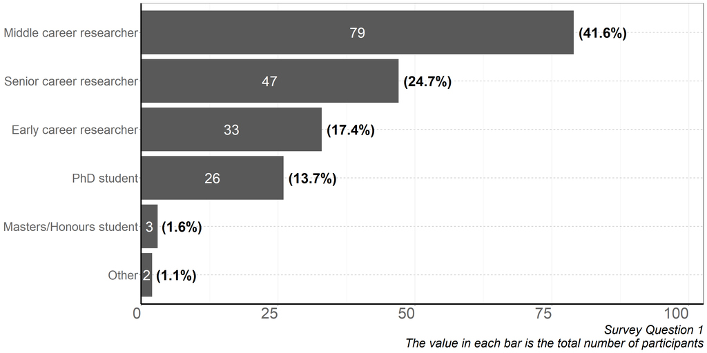

```r
# Separate rows and count total
total_career_stage_count <- dat %>%
  separate_rows(Q1, sep = ",\\s*") %>%
  filter(!is.na(Q1)) %>%
  count(Q1) %>%
  arrange(desc(n))

# Calculate count as a percentage
total_career_stage_percentage <-  total_career_stage_count %>%
  mutate(proportion = n/sum(total_career_stage_count$n),
         percentage = proportion*100)

# Theme for all MATES plots
MATES_theme <-  function(){
  theme_bw() +
  theme(
    panel.grid.major.y = element_line(color = "gray", linetype = "dashed"),
    panel.grid.minor.y = element_blank(),
    axis.line.x = element_line(linewidth = 1.2),
    axis.line.y = element_line(linewidth = 1.2),
    axis.title.x = element_blank(),
    axis.title.y = element_blank(),
    axis.text.x = element_text(hjust = 1, size = 25, color = "#666666"),
    axis.text.y = element_text(size = 20, color = "#666666"),
    legend.position = "none",
    plot.caption = element_text(size = 20, face = "italic")
  )
  }

# Plot for survey question 1
fig_Q1 <-  total_career_stage_count %>%
  ggplot(aes(x = n, y =reorder(Q1, n)), hjust = 0.5) +
  geom_bar(stat = "identity") +
  geom_text(aes(label = n, x = n/2 ,y = reorder(Q1,n)), hjust = 0.5, size = 8, color = "white") +
  geom_text(data = total_career_stage_percentage, aes(label = paste0("(", round(percentage, 1), "%)"), x = n),
            hjust = -0.1, size = 8, color = "black", fontface = "bold") +
  scale_fill_identity(guide = "none") +
  scale_x_continuous(expand = c(0,0), limits = c(0, max(total_career_stage_count$n*1.3))) +
  MATES_theme() +
  labs(caption = "Survey Question 1\nThe value in each bar is the total number of participants")

fig_Q1
```

```r
# ggsave(here("survey_results", "fig_Q1.jpg"),  width = 16, height = 8, units = "cm", scale = 2, dpi = 120)
```

## Survey Question 2

What is your current experience with meta-analyses?

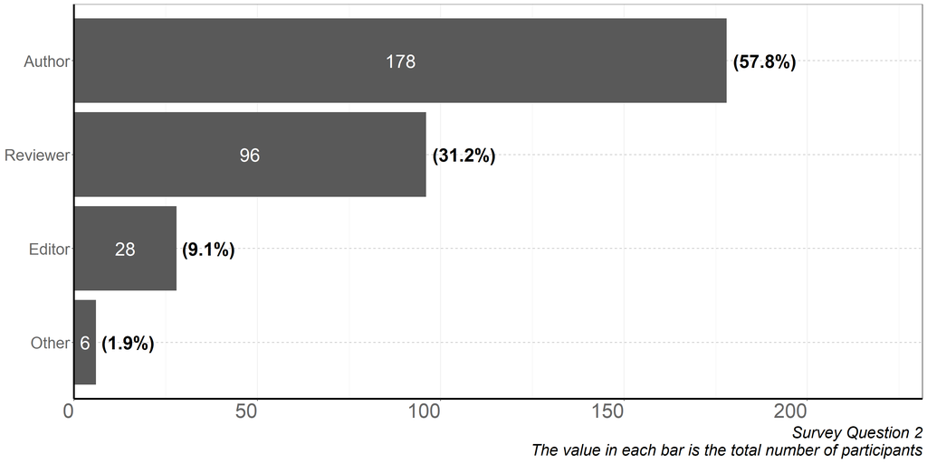

```r
# Separate rows and count total
total_ma_experience_count <- dat %>%
  separate_rows(Q2, sep = ",\\s*") %>%
  filter(!is.na(Q2)) %>%
  count(Q2) %>%
  arrange(desc(n))

# Calculate count as a percentage
total_ma_experience_percentage <-  total_ma_experience_count %>%
  mutate(proportion = n/sum(total_ma_experience_count$n),
         percentage = proportion*100)

# Plot for survey question 2
fig_Q2 <-  total_ma_experience_count %>%
  ggplot(aes(x = n, y =reorder(Q2, n)), hjust = 0.5) +
  geom_bar(stat = "identity") +
  geom_text(aes(label = n, x = n/2 ,y = reorder(Q2,n)), hjust = 0.5, size = 8, color = "white") +
  geom_text(data = total_ma_experience_percentage, aes(label = paste0("(", round(percentage, 1), "%)"), x = n),
            hjust = -0.1, size = 8, color = "black", fontface = "bold") +
  scale_fill_identity(guide = "none") +
  scale_x_continuous(expand = c(0,0), limits = c(0, max(total_ma_experience_count$n*1.3))) +
  MATES_theme() +
  labs(caption = "Survey Question 2\nThe value in each bar is the total number of participants")

fig_Q2
```

```r
# ggsave(here("survey_results", "fig_Q2.jpg"),  width = 16, height = 8, units = "cm", scale = 2, dpi = 120 )
```

## Question 3

What is your experience with systematic review or meta-analyses appraisal tools?

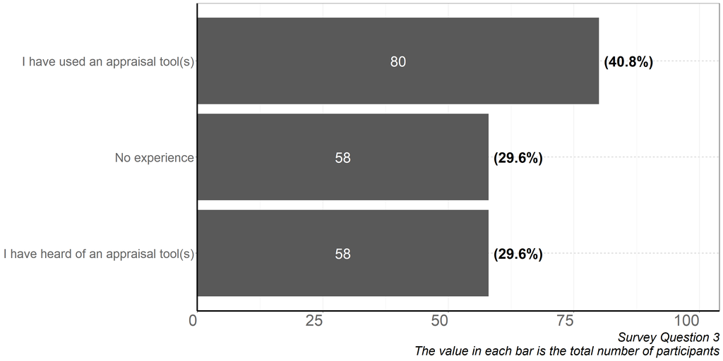

```r
# Separate rows and count total
total_appraisal_tool_experience_count <- dat %>%
  separate_rows(Q3, sep = ",\\s*") %>%
  filter(!is.na(Q3)) %>%
  count(Q3) %>%
  arrange(desc(n))

# Calculate count as a percentage
total_appraisal_tool_experience_percentage <-  total_appraisal_tool_experience_count %>%
  mutate(proportion = n/sum(total_appraisal_tool_experience_count$n),
         percentage = proportion*100)

# Plot for survey question 3
fig_Q3 <-  total_appraisal_tool_experience_count %>%
  ggplot(aes(x = n, y =reorder(Q3, n)), hjust = 0.5) +
  geom_bar(stat = "identity") +
  geom_text(aes(label = n, x = n/2 ,y = reorder(Q3,n)), hjust = 0.5, size = 8, color = "white") +
  geom_text(data = total_appraisal_tool_experience_percentage, aes(label = paste0("(", round(percentage, 1), "%)"), x = n),
            hjust = -0.1, size = 8, color = "black", fontface = "bold") +
  scale_fill_identity(guide = "none") +
  scale_x_continuous(expand = c(0,0), limits = c(0, max(total_appraisal_tool_experience_count$n*1.3))) +
  MATES_theme() +
  labs(caption = "Survey Question 3\nThe value in each bar is the total number of participants")


fig_Q3
```

```r
# ggsave(here("survey_results", "fig_Q3.jpg"),  width = 16, height = 8, units = "cm", scale = 2, dpi = 120 )
```

```r
# Filter dataframe for question 3
df_Q3 <- dat %>%
  filter(!is.na(Q3_1_TEXT)) %>%
  select(Q3_1_TEXT)

# Table for question 3
 kable(df_Q3, "html") %>%
    kable_styling("bordered", position = "left") %>%
    scroll_box(width = "150%", height = "400px")
```

| Q3_1_TEXT |
| --- |
| PRISMA |
| AMSTAR |
| PRISMA and R packages e.g. Metafor |
| CEESAT |
| metafor package |
| AMSTAR2; ROBIS; CASP; JBI |
| MetaWin, R |
| AMSTAR 2 |
| JBI |
| EPHPP |
| R-Studio, Matlab |
| Vos viewer |
| R ; Comprehensive meta-analysis |
| Custom OHAT tool |
| Econometric regression analysis |
| Collaboration for environmental evidence (CEE) scoring system |
| CEESAT |
| AMSTAR, CASP, ROBINS2 |
| PRISMA |
| CEESAT, CEECAT |
| CEESAT |
| RevMan |
| ROSES, PRISMA |
| MMAT, RoB-2 (somewhat), AMSTAR2, CEEDER, but I also built custom appraisal tools for reviews |
| AMSTAR 2 & ROBIS |
| used a framework published in an article |
| https://soil.copernicus.org/articles/9/117/2023/ |
| Armstar + other standard quality criteria published in the literature |
| PRISMA |
| AMSTAR, ROBIS |
| CEESAT |
| Cochrane, CASP, ROBINS |
| PRISMA, EFSA CATs |
| OpenMee software |
| metafor |
| CEESAT |
| If PRISMA counts, I have followed that tool before (and still attempt to). |
| CEESAT |
| PRISMA |
| JBI, CASP, BMJ Appraisal Tool |
| I have used metfor package in r and estimated effect size |
| CEESAT |
| JBI |
| PRISMA, PICO, PECO |
| PRISMA2020 |
| ROBIS, AMSTAR2 |
| CEESAT |
| Mostly those relating to health and medicine. Eg OHAT, and Newcastle-Ottawa Scale (NOS) |
| For assessing reporting, various PRISMA iterations, Strobe and I developed a modified version of STROBE for particular data collection method (unpublished).Many others for the appraisal of risk of bia… |
| OHAT Risk of Bias Rating Tool for Human and Animal Studies; Newcastle-Ottawa Scale |
| PRISMA, PICO, PECO |
| JBI, NOS, Navigation Guide, OHAT, ROBINS-E |
| R Software |
| Prisma |
| PRISMA |
| review-specific |
| Office for Health Assessment and Translation (OHAT) |
| not myself |
| I’ve used meta-analyses |
| GRADE; AMSTAR; NOS |
| CEECAT |
| systematic literature review for ecosystem services |
| Cochrane risk of bias; JBI tools; ROBINS-I |
| We used the tool developed by Konno et al (2021) for critical appraisal of study validity. REF: Konno K, Livoreil B, Pullin A. Collaboration for Environmental Evidence Critical Appraisal Tool version … |
| CEESAT |

```r
# write_csv(df_Q3, file = here("survey_results", "df_Q3.csv"))
```

## Question 4

What is the importance of reporting the software used to conduct the meta-analysis to the quality of reporting?

Referring to MATES item 1:

Do the authors report the software used to conduct the analysis within the manuscript or supplementary material?

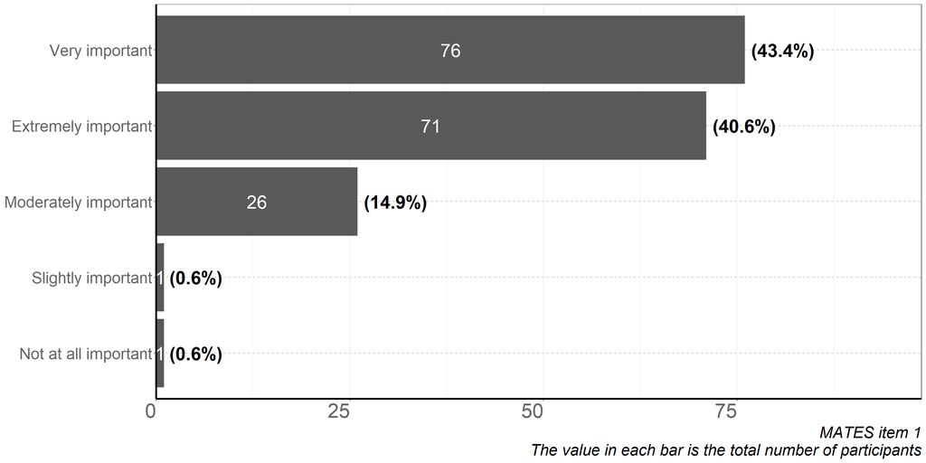

```r
# Separate rows and count total
total_software_importance_count <- dat %>%
  filter(!is.na(Q4)) %>%
  count(Q4) %>%
  arrange(desc(n))

# Calculate count as a percentage
total_software_importance_percentage <-  total_software_importance_count %>%
  mutate(proportion = n/sum(total_software_importance_count$n),
         percentage = proportion*100)

# Plot for survey question 4
fig_Q4 <-  total_software_importance_count %>%
  ggplot(aes(x = n, y =reorder(Q4, n)), hjust = 0.5) +
  geom_bar(stat = "identity") +
  geom_text(aes(label = n, x = n/2 , y = reorder(Q4,n)), hjust = 0.5, size = 8, color = "white") +
 geom_text(data = total_software_importance_percentage, aes(label = paste0("(", round(percentage, 1), "%)"), x = n),
            hjust = -0.1, size = 8, color = "black", fontface = "bold") +
  scale_fill_identity(guide = "none") +
  scale_x_continuous(expand = c(0,0), limits = c(0, max(total_software_importance_count$n*1.3))) +
  MATES_theme() +
  labs(caption = "MATES item 1\nThe value in each bar is the total number of participants")


fig_Q4
```

```r
# ggsave(here("survey_results", "fig_Q4.jpg"),  width = 16, height = 8, units = "cm", scale = 2, dpi = 120 )
```

## Question 5

Comments on MATES item 1 (e.g., potential improvements or a justification of response)

```r
# Filter dataframe for question 5
df_Q5 <- dat %>%
  filter(!is.na(Q5)) %>%
  select(c(Q4,Q5))

# Table for question 5
 kable(df_Q5, "html") %>%
    kable_styling("bordered", position = "left") %>%
    scroll_box(width = "150%", height = "400px")
```

| Q4 | Q5 |
| --- | --- |
| Extremely important | The software used for analysis help reviewers and readers understand the nuances in the methodology used and provide transparency for repeatability. |
| Extremely important | It should be more and more convenient and accessible for authors to use. |
| Moderately important | Analysis methods is more important than software |
| Extremely important | So that it can be replicated. I like R because the code and data can be published. RevMan which a lot of people use has its own format. |
| Very important | Different softwares can have differnet biases, so it has to be reported |
| Extremely important | Reporting the software used to conduct the meta-analysis is important for several reasons. First, it allows other researchers to replicate the analysis and to verify the results. Second, it provides i… |
| Extremely important | This practice enhances transparency and reproducibility in research, allowing readers to understand and potentially replicate the analysis. Providing information about the software used is also crucia… |
| Very important | State the tools used clearly in the methodology |
| Very important | Each software are based on specific algorithm, e.g. for the tau2 estimators, …. |
| Extremely important | It is important to assist future researchers who are not as experience, but it also allows greater repeatability. i.e., when two different groups argue about responses using two different software is … |
| Very important | Systematic review data is complex and has multi-dimensional relationships and therefore the manner in which the data is collated and stored needs to be robust (e.g. in a relational database) |
| Very important | Perhaps be more specific or provide examples of when software would be used (literature screening, analysis etc) |
| Moderately important | No comments. |
| Very important | Since some analyzes may not be performed by all statistical software, it is necessary to mention this point. |
| Extremely important | The used software can affect the quality of the results and respective conclusions. |
| Extremely important | I am still learning |
| Very important | including version |
| Extremely important | no comment |
| Very important | One could generally think of having a more differentiated assessment: Full reporting (including versions), partial reporting and no reporting, to reduce the number of questions. Will make this comment… |
| Moderately important | This matters less (or doesn’t) if the methods are well and fully described |
| Extremely important | It might be worth splitting the statistical analysis from software used for screening and summarising the inclusion of articles. |
| Extremely important | The type of software is important to work towards a standardization of meta-analysis methods |
| Moderately important | The software alone is not very important. It is more relevant to report (i) the statistical methods/models, and (ii) the code. |
| Extremely important | Perhaps an intermediate response could involve the software for analysis being indicated but other software not. I understand that the questions mainly target the statistical analysis itself. But if t… |
| Very important | processing mode and error level |
| Very important | Yes I think it’s important to note the software used. But I do think you’ll have to be clearer on the ‘software’ to report. For instance, the ‘yes’ example for this item is the citation of RStudio. It… |
| Extremely important | This is probably provided later on, but I think authors should also provide their meta-analysis code and data as well. |
| Extremely important | This is an important piece of information that the reviewer should know when assessing the quality of the reported information. |
| Very important | I it important report software to assess the quality of results |
| Very important | Overall approach and full disclosure is necessary. However, quality of analysis should go beyond software usage. |
| Very important | The use of software allows us to be more rigorous in the selection of manuscripts and quality analysis, avoiding errors. |
| Very important | Each tool can be based on certain points, for example, focusing on the keywords existing within the text but it can be used by the author as an example not the main topic of the paper |
| Moderately important | Several softwares are available, better than software, the exact model implemented is very relevant (e.g. random versus fixed model) |
| Very important | Good question. |
| Extremely important | None |
| Extremely important | Synergizing MATES with real time data from different locality |
| Extremely important | The software and packages need to be reported to allow for the MA to be repeated, and for appraisal of potential bias |
| Extremely important | Beside the obvious intent of providing enough info for repeatability, you also acknowledge the work of the people allowing you to do your work,which is fair and ethical. |
| Extremely important | Quality and replication of data |
| Extremely important | As part of the methodology, authors should report the software used to conduct the meta-analysis. This is for transparency, and also to train readers and new researchers in the field. |
| Very important | I think this is very important because different software may yield different results. For example, using Google Scholar vs. Web of Science will likely show different publications. Differences in resu… |
| Very important | configuration/options in some software are also important, although those may be covered in other parts of the methodology |
| Moderately important | According to my experience, software is not important for doing meta-analysis, and the results from different softwares are always similar |
| Very important | To ensure accurate comparison, reproduction, and discussion of results, it is crucial to provide detailed information about the software used for analysis. Even slight differences in software versions… |
| Extremely important | I think it is very important that all steps in conducting the meta-analyses are reported so that the process is as transparent as possible. Beyond reporting the software used, I think it is important … |
| Extremely important | It’s extremely important for transparency and reproducibility; and for future updates and revisions. |
| Moderately important | With no knowledge about what such a software does, this question is difficult for me to answer. |
| Extremely important | As in all research, reproducability is important. Therefore, the software used should clearly be stated. |

```r
# write_csv(df_Q5, file = here("survey_results", "df_Q5.csv"))
```

## Question 6

What is the importance of reporting the packages used to conduct the meta-analysis to the quality of reporting?

Referring to MATES item 2:

Do the authors report the packages used to conduct the analysis within the manuscript or supplementary material?

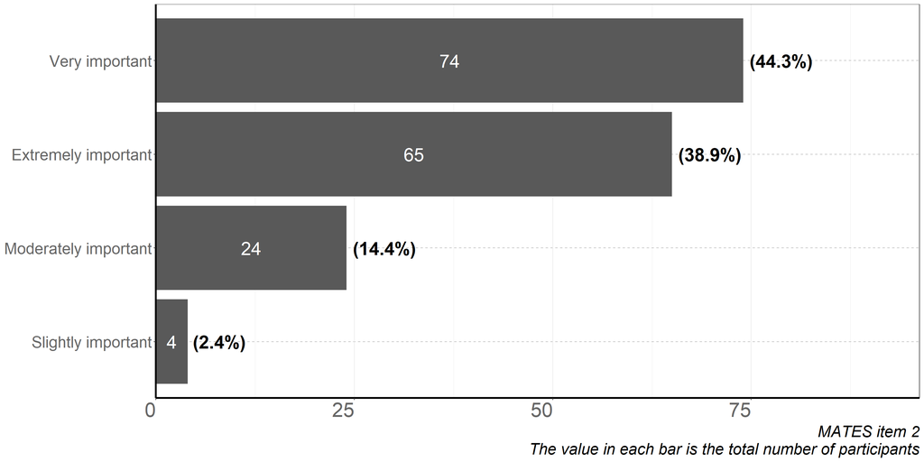

```r
# Separate rows and count total
total_package_importance_count <- dat %>%
  filter(!is.na(Q6)) %>%
  count(Q6) %>%
  arrange(desc(n))

# Calculate count as a percentage
total_package_importance_percentage <-  total_package_importance_count %>%
  mutate(proportion = n/sum(total_package_importance_count$n),
         percentage = proportion*100)

# Plot for survey question 6
fig_Q6 <-  total_package_importance_count %>%
  ggplot(aes(x = n, y =reorder(Q6, n)), hjust = 0.5) +
  geom_bar(stat = "identity") +
  geom_text(aes(label = n, x = n/2 , y = reorder(Q6,n)), hjust = 0.5, size = 8, color = "white") +
 geom_text(data = total_package_importance_percentage, aes(label = paste0("(", round(percentage, 1), "%)"), x = n),
            hjust = -0.1, size = 8, color = "black", fontface = "bold") +
  scale_fill_identity(guide = "none") +
  scale_x_continuous(expand = c(0,0), limits = c(0, max(total_package_importance_count$n*1.3))) +
  MATES_theme() +
  labs(caption = "MATES item 2\nThe value in each bar is the total number of participants")


fig_Q6
```

```r
# ggsave(here("survey_results", "fig_Q6.jpg"),  width = 16, height = 8, units = "cm", scale = 2, dpi = 120 )
```

## Question 7

Comments on MATES item 2 (e.g., potential improvements or a justification of response)

```r
# Filter for question 7
df_Q7 <- dat %>%
  filter(!is.na(Q7)) %>%
  select(c(Q6,Q7))

# Table for question 7
 kable(df_Q7, "html") %>%
    kable_styling("bordered", position = "left") %>%
    scroll_box(width = "150%", height = "400px")
```

| Q6 | Q7 |
| --- | --- |
| Very important | The packages used for analysis help reviewers and readers understand the nuances in the methodology used and provide transparency for repeatability. |
| Extremely important | Beside reporting the package used for meta-analysis, some essential methods in the package should be described to facilitate readers’ understanding and appraising the results. |
| Extremely important | Different packages have different methods |
| Extremely important | Same as before |
| Extremely important | Different packages can give different results, so this increases repeatability |
| Very important | Acesso gratuito e cursos |
| Extremely important | Reporting the packages used to conduct the meta-analysis is important for the same reasons as reporting the software used. Additionally, it can be helpful for other researchers to know which packages … |
| Very important | For software that works with packages like R, the reporting of packages is as important as reporting the software itself, because without this information, the reader does not know what was done. |
| Extremely important | It is crucial for transparency and reproducibility in research to provide information about the software used. This allows readers to understand and replicate the analysis, which is important for the … |
| Very important | The results could be replicated |
| Very important | Same remark as before. Need also to provide clearly the equation in the main text, (and/or the script in supp mat) |
| Extremely important | Same as comments on item 1 |
| Very important | Some analysis should be done with a specific R package. |
| Very important | Perhaps this does not apply to all types of meta-analysis software, but I guess this can be selected as N/A. |
| Very important | Would this apply to all software that would be used, or only a subset? |
| Extremely important | Important for replication of results |
| Extremely important | Still learning MATES |
| Slightly important | To my experience package is imprtant when using R. There might be other metanalysis tools (Sigma Stat, SPSS, Excel) |
| NA | I am not sure i understand the framing “report the packages”. Software packages? |
| Moderately important | I’d rather have the model/methods well described but if not, the package at least gives you a starting point for what was likely done (is assume defaults likely used) |
| Very important | It is vital to reproduce the analysis. |
| Extremely important | The report of software packages is important to work towards a standardization of meta-analysis methods |
| Very important | As said above, it is important to report the code + the statistical methods/models. The sofware and package are useful elements but are not sufficient alone. |
| Very important | so others can see how useful it is and use or not use it. |
| Very important | Need some explanation abuot what packages are. |
| Extremely important | I use R and understand the importance of citing packages. But do all softwares actually have “packages”? |
| Moderately important | I feel that there is overlap between item 1 and 2 and 3, or at least some overlap. I think that this could be simplified into 1 item for which at least some component of these three is mentioned |
| Moderately important | generally the author has the data available to verify what has been reported |
| Very important | Not necessarily crucial if clear within documented code, but ideal. |
| Very important | This is important, but perhaps additional detail could be given around the packages pertinent to the analysis. I personally use tons of different R packages but citing all of them would be tedious and… |
| Extremely important | May require some language specification as some people use “package” and “software” interchangeably. |
| Extremely important | When reporting the software, it is important to report both the package and the version numbers to ensure latest and appropriate tools have been used in the analysis. |
| Moderately important | Software packages change, but usually not significantly. Relevance of meta-analysis should go beyond versions/packages of software. It’s not a problem if mentioned, but I won’t shot down a contributio… |
| Extremely important | Meta-analyses must be carried out with some software to be more efficient in the statistical analysis of the chosen measure of association. |
| Moderately important | The difference between this and the previous question regarding software could be clearer |
| Extremely important | Not only the packages, but also their version. |
| Moderately important | packages Can be changed very fast over time, and it has no meaning to know about not existing package! |
| Very important | Specify the version of the package |
| Moderately important | As before, several softwares are available, generally with one official package for MA. |
| Very important | Important, but keep in mind that “packages” is language most relevant when using R/Python as the analysis platform. |
| Very important | It is important |
| Extremely important | Important for repeatability and appraisal of potential biases |
| Very important | it is important to report the quality or at least have a critical assessment of the quality |
| Very important | Your paper must provide enough information that your work could be repeated. Editors and referees will certainly read your text with an eye for repeatability. |
| Extremely important | Reproducibility |
| Extremely important | As part of the methodology, authors should report the packages used to conduct the analysis. This is for transparency, and also to train readers and new researchers in the field. |
| Very important | It is important if you use software like R. In CMA, it seems not relevant. |
| Very important | Please refer to my comment on the last question! |
| Very important | The utmost important thing happens before MATES comes into play: professional data stratification. This is where ALL meta-analysis in ecology - plant sciences I have seen failed completely. The reason… |
| Slightly important | Still, this would be useful for other authors to replicate the review, but for meta-analysis itself is not important |
| Very important | If the package has slight differences that can result in distinct outcomes, it will be the same as the previous question. Then is it important report the details. |
| Very important | Reporting needs to be clear and precise, and main packages (and versions used) should be reported. Since the number of packages can quickly add up, additional packages could be listed in the scripts. |
| Extremely important | It’s extremely important for others to understand the methodology, and support the study’s validity. |
| Moderately important | Same remark as before applies here. |

```r
# write_csv(df_Q7, file = here("survey_results", "df_Q7.csv"))
```

## Question 8

What is the importance of reporting the version numbers of the software used to conduct the meta-analysis to the quality of reporting?

Referring to MATES item 3:

Do the authors report the version numbers of the software used within the manuscript or supplementary material?

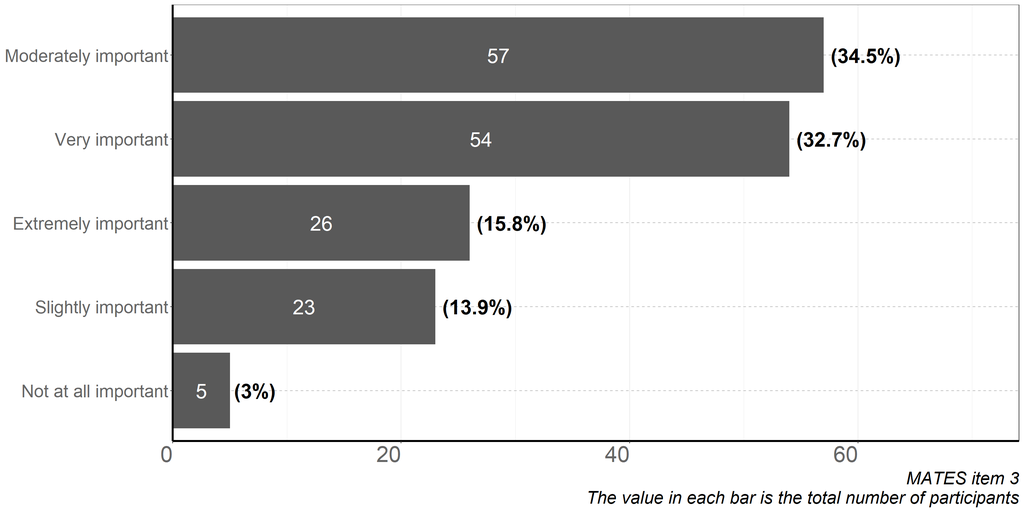

```r
# Separate rows and count total
total_version_importance_count <- dat %>%
  filter(!is.na(Q8)) %>%
  count(Q8) %>%
  arrange(desc(n))

# Calculate count as a percentage
total_version_importance_percentage <-  total_version_importance_count %>%
  mutate(proportion = n/sum(total_version_importance_count$n),
         percentage = proportion*100)

# Plot for survey question 8
fig_Q8 <-  total_version_importance_count %>%
  ggplot(aes(x = n, y =reorder(Q8, n)), hjust = 0.5) +
  geom_bar(stat = "identity") +
  geom_text(aes(label = n, x = n/2 , y = reorder(Q8,n)), hjust = 0.5, size = 8, color = "white") +
 geom_text(data = total_version_importance_percentage, aes(label = paste0("(", round(percentage, 1), "%)"), x = n),
            hjust = -0.1, size = 8, color = "black", fontface = "bold") +
  scale_fill_identity(guide = "none") +
  scale_x_continuous(expand = c(0,0), limits = c(0, max(total_version_importance_count$n*1.3))) +
  MATES_theme() +
  labs(caption = "MATES item 3\nThe value in each bar is the total number of participants")


fig_Q8
```

```r
# ggsave(here("survey_results", "fig_Q8.jpg"),  width = 16, height = 8, units = "cm", scale = 2, dpi = 120 )
```

## Question 9

Comments on MATES item 3 (e.g., potential improvements or a justification of response)

```r
# Filter for question 9
df_Q9 <- dat %>%
  filter(!is.na(Q9)) %>%
  select(c(Q8,Q9))

# Table for question 9
 kable(df_Q9, "html") %>%
    kable_styling("bordered", position = "left") %>%
    scroll_box(width = "150%", height = "400px")
```

| Q8 | Q9 |
| --- | --- |
| Moderately important | Package versions can be important if substantial changes are made to functions because changes may alter the reproducibility and transparency of analysis. Tight word counts on journals can make this l… |
| Extremely important | Noval versions are generally more preferred. |
| Extremely important | It all goes together, if you say what you are using give the version number. It is probably more important with R than RevMan because R is more dynamic - especially metafor which they do a great job o… |
| Extremely important | Different versions can give slightly different results |
| Very important | Reporting the version numbers of the software used to conduct the meta-analysis is important because different versions of software may have different features and functionality. By reporting the vers… |
| Moderately important | version numbers of software packages are part of the reporting in scientific publications. However, the way packages work are often not changing among versions, so maybe moderately important after all… |
| Very important | Understand the up-to-date info |
| Moderately important | I have never really though about this. |
| Very important | Very important, but perhaps I would not expect too much difference between (say) different versions of R |
| Slightly important | Software version numbers change regularly but this shouldn’t significantly alter the quality of the review |
| Very important | To make it clear to different audiences (understanding) |
| Slightly important | Only truly important if major changes to default method made and if actual methods underlying analysis made by program are poorly described. |
| Very important | As before, vital for reproducibility. |
| Moderately important | The version is important for understading the updates of the software at the time of analysis. |
| Very important | See my comment above |
| Extremely important | In some sense I don’t necessarily think something like this is liable to make much difference to the outcomes of the analysis, but it seems so easy to report this information that I can’t see why it w… |
| Slightly important | see my comment on item 2 |
| Moderately important | changes in reporting mode, error level, type of functions |
| Very important | Depends on the package or software used, in case there are major updates between versions I would say yes. |
| Very important | Not unresolvable if not, but clearly ideal |
| Slightly important | I don’t find this item *too* severely important, but I can see it (e.g., ‘brms’ is still sort of maturing right now so version number could be helpful). But this item is moot if authors share the work… |
| Moderately important | Version number isn’t terribly important if the authors also provide code and data. |
| Extremely important | When reporting the software, it is important to report both the package and the version numbers to ensure latest and appropriate tools have been used in the analysis. |
| Slightly important | see my earlier comment |
| Very important | It allows knowing the extensions and types of quantitative analyzes for a meta-analysis that the authors can apply with the software. If the analysis is limited due to the age of the software, the aut… |
| Very important | Does this need to be a separate question, could the first not be ‘report software and version number’? |
| Extremely important | Nevermind my previous comment |
| Not at all important | The version improved over time mostly to fix errors and add features. Not related to the main functions. |
| Moderately important | This is relevant due to changes across years (e.g. metan before Stata 16 and meta set routine from Stata 16). |
| Very important | This is only really important if there have been changes that impact the results/ introduce bias, so probably safer to include than not |
| Slightly important | the version sometimes refers to specific features which may or may not be relevant. Actually it is not very important for the quality of the analysis as such, but as long as it is stated, it is suffic… |
| Very important | Full development In addition to “research ethics”, the presentation of statistical tools and data background is underpinned by a strong focus on systematizing research in order to share current knowle… |
| Extremely important | Data quality |
| Slightly important | As part of the methodology, authors should report the software version used to conduct the meta-analysis. But lack of reporting the version, as long as the software is reported should not penalize the… |
| Moderately important | I think that reporting version numbers of specific packages may be more important. I am not sure how much difference there is between, say, R version 2.1 and R version 2.2, whereas statistical softwar… |
| Very important | standard procedure |
| Not at all important | No |
| Very important | New versions have improvements or changes in the algorithms or the routines that can make differences. |
| Very important | See my previous answer ;) |
| Moderately important | Need the version number for technical support and troubleshooting, if necessary. |
| Extremely important | I believe this is indeed very important for repeatability purposes |
| Moderately important | Same remark as before applies here. |

```r
# write_csv(df_Q9, file = here("survey_results", "df_Q9.csv"))
```

## Question 10

What is the importance of reporting the code used to conduct the meta-analysis to the quality of reporting?

Referring to MATES item 4:

Do the authors report the relevant code to conduct the analysis within the manuscript, supplementary material or an attached repository?

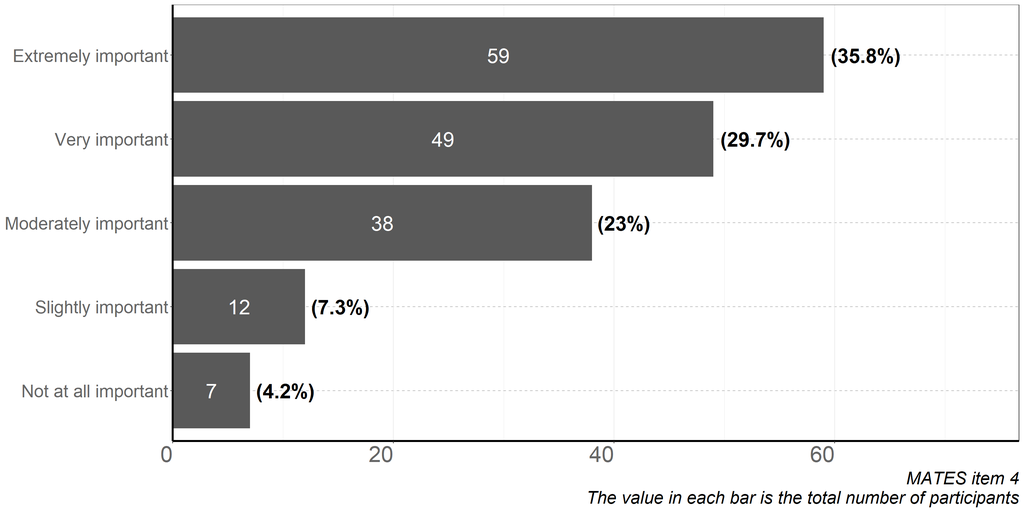

```r
# Seperate rows and count total
total_code_importance_count <- dat %>%
  filter(!is.na(Q10)) %>%
  count(Q10) %>%
  arrange(desc(n))

# Calculate count as a percentage
total_code_importance_percentage <-  total_code_importance_count %>%
  mutate(proportion = n/sum(total_code_importance_count$n),
         percentage = proportion*100)

# Plot for survey question 10
fig_Q10 <-  total_code_importance_count %>%
  ggplot(aes(x = n, y =reorder(Q10, n)), hjust = 0.5) +
  geom_bar(stat = "identity") +
  geom_text(aes(label = n, x = n/2 , y = reorder(Q10,n)), hjust = 0.5, size = 8, color = "white") +
 geom_text(data = total_code_importance_percentage, aes(label = paste0("(", round(percentage, 1), "%)"), x = n),
            hjust = -0.1, size = 8, color = "black", fontface = "bold") +
  scale_fill_identity(guide = "none") +
  scale_x_continuous(expand = c(0,0), limits = c(0, max(total_code_importance_count$n*1.3))) +
  MATES_theme() +
  labs(caption = "MATES item 4\nThe value in each bar is the total number of participants")

fig_Q10
```

```r
# ggsave(here("survey_results", "fig_Q10.jpg"),  width = 16, height = 8, units = "cm", scale = 2, dpi = 120 )
```

## Question 11

Comments on MATES item 4 (e.g., potential improvements or a justification of response)

```r
# Filter for question 11
df_Q11 <- dat %>%
  filter(!is.na(Q11)) %>%
  select(c(Q10,Q11))

# Table for question 11
 kable(df_Q11, "html") %>%
    kable_styling("bordered", position = "left") %>%
    scroll_box(width = "150%", height = "400px")
```

| Q10 | Q11 |
| --- | --- |
| Moderately important | I think it can be important for transparency. Although, admittedly I still haven’t published the code for my meta-analysis. The PhD timeline has kept me from tidying it up into a format that would mak… |
| Very important | Disclosing the code is of much help to the scientific community. |
| Very important | You just can’t with RevMan - which is why R is better |
| Very important | At least a sample code should be reported, so the tiny factors that can cause differences can be controlled |
| Extremely important | Reporting the code used to conduct the meta-analysis is important for several reasons. First, it allows other researchers to replicate the analysis and to verify the results. Second, it provides infor… |
| Slightly important | Code helps for absolute transparency, but should not be necessary if the used models are fully described. |
| Very important | Verification, Transparency and reproducible |
| Extremely important | The work can be replicated and learn among the public/readers |
| Very important | The best for transparency and reproducibility |
| Extremely important | This is important in many circumstances. For example, analyzing how the authors included random effects or estimates of regression style meta-analyses |
| Slightly important | Reporting of code can be very important when the meta-analytic methods are not standard or demand purpose-written code. |
| Extremely important | This is important but including the data file too is important for reproducibility. Retyping the tables to actual codes used is a barrier for review of reproducibility. |
| Moderately important | In the interests of open research the code may be useful to future authors conducting systematic reviews |
| Extremely important | Does this include the code for data wrangling and effect size calculation etc? Some studies might only include models used on processed data |
| Extremely important | I think the code is more important than the package or version information. Without the code the analysis is much more difficult to replicate. |
| Very important | Descriptions in methods sections are never precise or detailed enough to allow full replication of a study |
| Extremely important | this is an important aspect of reproducibility |
| Extremely important | I think reporting of code is probably the most important aspect for reproducibility and transparency |
| Very important | N/A |
| Moderately important | Matters most if methods inadequately described |
| Very important | Again important for all scientific reproducibility (not necessarily specific to meta-analysis though…) I wonder if these questions should be more specific for meta-analysis, rather than a repetition o… |
| Moderately important | The code is usefull for replicating the methods used, and to look for improvements/flaws in methods. |
| Extremely important | Yes, this is what is needed. |
| Extremely important | Not sure what is meant by an “attached” repository. Could”publically accessible” be better phrasing? |
| Slightly important | I dont know |
| Extremely important | It is important that the meta-analysis (or any data analysis) is reproducable. For that, you need the code. |
| Extremely important | items 2 and 3 rely on this. They would be useless without then getting the code. |
| Moderately important | Reporting the code is important for transparency, but if the methods are well described/reported the analysis should be repeatable |
| Extremely important | I’m a big advocate of this. But this item may need to generalise to those who don’t use a computational language (lest we discriminate against spreadsheet warriors). Valid meta-analyses can be done wi… |
| Extremely important | I’m not sure if “report the relevant code” is the right terminology. Perhaps “provide” or “include”. Otherwise, the wording seems fine and this, along with the data, are the most important aspects. |
| Very important | Even though this may not be considered as compulsory information during publication, reporting these provide transparent information the analysis process which is helpful in assessment. |
| Extremely important | The importance of reporting the code used in conducting a meta-analysis is fundamental to the quality of scientific reporting. It allows transparency and reproducibility of the analysis, review of the… |
| Very important | I use R so this is easy for me, but it may not be so easy for people using point-and-click software. It is good practice though. |
| Moderately important | The code will be useful to get only overall idea, but the research results include more than the code only! The author reviews the results and organizes them to be meaningful |
| Extremely important | Authors should report the main analysis code instead of replication code for figures |
| Moderately important | Helpful but rarely done due to risk of plagiarism. I would not ask for mandatory publication of code |
| Extremely important | Improves transparency and reproducibility. Also, enables new researchers with tools to better understand analytical steps in detail. |
| Slightly important | This is important for repeatability and detection of bias, however this will depend on which package is used. ‘User-friendly’ packages with relatively simple questions won’t report code as such. |
| Very important | only relevant if code was developed, or if there is a specific reason for choosing a particular code |
| Extremely important | for data analysis |
| Extremely important | Reliability of data |
| Moderately important | As part of the methodology, it is advisable that authors report the code. This would help in the transparency, and also to train new researchers in the field. |
| Extremely important | All of these relate to transparency |
| Not at all important | Good question. It’s certainly great if code is published, as it makes it easier to input data and see how the authors obtained certain results. However, if the overall reporting quality is bad, then c… |
| Moderately important | once the software and its version is reported, this seems like less important |
| Moderately important | It would be helpful for other researchers, but this can just be provided in the supplements |
| Extremely important | I think reporting the code should be considered a standard practice, as it helps with the repeatability and transparency of analyses, and also helps others learn how analyses can be conducted. For the… |
| Extremely important | The code has educational value. It’s extremely important for adhering to open science practices. |
| Very important | Here too, I believe this is very important for repeatability purposes and to be able to inspect/understand how researchers have conducted the meta-analysis. There can be a lot of arbitrary decisions m… |
| Moderately important | Same remark as before applies here. |

```r
# write_csv(df_Q11, file = here("survey_results", "df_Q11.csv"))
```